# Convolutional Neural Networks

## Project: Write an Algorithm for a Dog Identification App

### Why We're Here

In this notebook, I will develop an algorithm that could be used as part of a mobile or web app. At the end of this project, code will accept any user-supplied image as input. If a dog is detected in the image, it will provide an estimate of the dog's breed. If a human is detected, it will provide an estimate of the dog breed that is most resembling. The image below displays potential sample output of finished project.

[figure not shown]

In this real-world setting, it is required to piece together a series of models to perform different tasks; for instance, the algorithm that detects humans in an image will be different from the CNN that infers dog breed. There are many points of possible failure, and no perfect algorithm exists. Imperfect solution will, nonetheless, create a fun user experience!

### The Road Ahead

I have broken the notebook into separate steps. Feel free to use the links below to navigate the notebook.

- Step 0: Import Datasets
- Step 1: Detect Humans
- Step 2: Detect Dogs
- Step 3: Create a CNN to Classify Dog Breeds (from Scratch)
- Step 4: Create a CNN to Classify Dog Breeds (using Transfer Learning)
- Step 5: Write your Algorithm
- Step 6: Test Your Algorithm

## Step 0: Import Datasets

Download the required human and dog datasets:

- Download the [dog dataset](https://s3-us-west-1.amazonaws.com/udacity-aind/dog-project/dogImages.zip). Unzip the folder and place it in this project's home directory, at the location `/dog_images`.
- Download the [human dataset](https://s3-us-west-1.amazonaws.com/udacity-aind/dog-project/lfw.zip). Unzip the folder and place it in the home directory, at location `/lfw`.

*Note: If you are using a Windows machine, you are encouraged to use [7zip](http://www.7-zip.org/) to extract the folder.*

In the code cell below, I save the file paths for both the human (LFW) dataset and dog dataset in the numpy arrays `human_files` and `dog_files`.

```python
import numpy as np
from glob import glob

# load filenames for human and dog images
human_files = np.array(glob("/data/lfw/*/*"))
dog_files = np.array(glob("/data/dog_images/*/*/*"))

# print number of images in each dataset
print('There are %d total human images.' % len(human_files))
print('There are %d total dog images.' % len(dog_files))
```

```
There are 13233 total human images.
There are 8351 total dog images.
```

## Step 1: Detect Humans

In this section, I use OpenCV's implementation of [Haar feature-based cascade classifiers](http://docs.opencv.org/trunk/d7/d8b/tutorial_py_face_detection.html) to detect human faces in images.

OpenCV provides many pre-trained face detectors, stored as XML files on [github](https://github.com/opencv/opencv/tree/master/data/haarcascades). I have downloaded one of these detectors and stored it in the `haarcascades` directory. In the next code cell, I demonstrate how to use this detector to find human faces in a sample image.

```
Number of faces detected: 1
```

```python
import cv2
import matplotlib.pyplot as plt
%matplotlib inline

# extract pre-trained face detector
face_cascade = cv2.CascadeClassifier('haarcascades/haarcascade_frontalface_alt.xml')

# load color (BGR) image
img = cv2.imread(human_files[0])
# convert BGR image to grayscale
gray = cv2.cvtColor(img, cv2.COLOR_BGR2GRAY)

# find faces in image
faces = face_cascade.detectMultiScale(gray)

# print number of faces detected in the image
print('Number of faces detected:', len(faces))

# get bounding box for each detected face
for (x,y,w,h) in faces:
    # add bounding box to color image
    cv2.rectangle(img,(x,y),(x+w,y+h),(255,0,0),2)

# convert BGR image to RGB for plotting
cv_rgb = cv2.cvtColor(img, cv2.COLOR_BGR2RGB)

# display the image, along with bounding box
plt.imshow(cv_rgb)
plt.show()
```

[output not shown]

Before using any of the face detectors, it is standard procedure to convert the images to grayscale. The `detectMultiScale` function executes the classifier stored in `face_cascade` and takes the grayscale image as a parameter.

In the above code, `faces` is a numpy array of detected faces, where each row corresponds to a detected face. Each detected face is a 1D array with four entries that specifies the bounding box of the detected face. The first two entries in the array (extracted in the above code as `x` and `y`) specify the horizontal and vertical positions of the top left corner of the bounding box. The last two entries in the array (extracted here as `w` and `h`) specify the width and height of the box.

### Write a Human Face Detector

The following function returns `True` if a human face is detected in an image and `False` otherwise. This function, aptly named `face_detector`, takes a string-valued file path to an image as input and appears in the code block below.

```python
# returns "True" if face is detected in image stored at img_path
def face_detector(img_path):
    img = cv2.imread(img_path)
    gray = cv2.cvtColor(img, cv2.COLOR_BGR2GRAY)
    faces = face_cascade.detectMultiScale(gray)
    return len(faces) > 0
```

### Assess the Human Face Detector

**Question 1:** Use the code cell below to test the performance of the `face_detector` function.

- What percentage of the first 100 images in `human_files` have a detected human face?
- What percentage of the first 100 images in `dog_files` have a detected human face?

Ideally, We would like 100% of human images with a detected face and 0% of dog images with a detected face. You will see that this algorithm falls short of this goal, but still gives acceptable performance. I extract the file paths for the first 100 images from each of the datasets and store them in the numpy arrays `human_files_short` and `dog_files_short`.

```python
from tqdm import tqdm

human_files_short = human_files[:100]
dog_files_short = dog_files[:100]

#-#-# Do NOT modify the code above this line. #-#-#

## TODO: Test the performance of the face_detector algorithm
## on the images in human_files_short and dog_files_short.

human_file_face_count = 0
dog_file_face_count = 0

for hf in human_files_short:
    if face_detector(hf):
        human_file_face_count += 1

print('Percentage of human faces in (first 100) human files:', human_file_face_count / 100 * 100)

for df in dog_files_short:
    if face_detector(df):
        dog_file_face_count += 1

print('Percentage of human faces in (first 100) dog files:', dog_file_face_count / 100 * 100)
```

```
Percentage of human faces in (first 100) human files: 98.0
Percentage of human faces in (first 100) dog files: 17.0
```

The face detector from OpenCV is a potential way to detect human images in algorithm, but there are other approaches too that make use of deep learning :). Code cell below is to design and test other face detection algorithm. Also report performance on `human_files_short` and `dog_files_short`.

```python
### (Optional)
### TODO: Test performance of anotherface detection algorithm.
```

## Step 2: Detect Dogs

In this section, I use a [pre-trained model](http://pytorch.org/docs/master/torchvision/models.html) to detect dogs in images.

### Obtain Pre-trained VGG-16 Model

The code cell below downloads the VGG-16 model, along with weights that have been trained on [ImageNet](http://www.image-net.org/), a very large, very popular dataset used for image classification and other vision tasks. ImageNet contains over 10 million URLs, each linking to an image containing an object from one of [1000 categories](https://gist.github.com/yrevar/942d3a0ac09ec9e5eb3a).

```python
import torch
import torchvision.models as models

# define VGG16 model
VGG16 = models.vgg16(pretrained=True)

# check if CUDA is available
use_cuda = torch.cuda.is_available()

# move model to GPU if CUDA is available
if use_cuda:
    VGG16 = VGG16.cuda()

print(VGG16)
```

```
VGG(
  (features): Sequential(
    (0): Conv2d(3, 64, kernel_size=(3, 3), stride=(1, 1), padding=(1, 1))
    (1): ReLU(inplace)
    (2): Conv2d(64, 64, kernel_size=(3, 3), stride=(1, 1), padding=(1, 1))
    (3): ReLU(inplace)
    (4): MaxPool2d(kernel_size=2, stride=2, padding=0, dilation=1, ceil_mode=False)
    (5): Conv2d(64, 128, kernel_size=(3, 3), stride=(1, 1), padding=(1, 1))
    (6): ReLU(inplace)
    (7): Conv2d(128, 128, kernel_size=(3, 3), stride=(1, 1), padding=(1, 1))
    (8): ReLU(inplace)
    (9): MaxPool2d(kernel_size=2, stride=2, padding=0, dilation=1, ceil_mode=False)
    (10): Conv2d(128, 256, kernel_size=(3, 3), stride=(1, 1), padding=(1, 1))
    (11): ReLU(inplace)
    (12): Conv2d(256, 256, kernel_size=(3, 3), stride=(1, 1), padding=(1, 1))
    (13): ReLU(inplace)
    (14): Conv2d(256, 256, kernel_size=(3, 3), stride=(1, 1), padding=(1, 1))
    (15): ReLU(inplace)
    (16): MaxPool2d(kernel_size=2, stride=2, padding=0, dilation=1, ceil_mode=False)
    (17): Conv2d(256, 512, kernel_size=(3, 3), stride=(1, 1), padding=(1, 1))
    (18): ReLU(inplace)
    (19): Conv2d(512, 512, kernel_size=(3, 3), stride=(1, 1), padding=(1, 1))
    (20): ReLU(inplace)
    (21): Conv2d(512, 512, kernel_size=(3, 3), stride=(1, 1), padding=(1, 1))
    (22): ReLU(inplace)
    (23): MaxPool2d(kernel_size=2, stride=2, padding=0, dilation=1, ceil_mode=False)
    (24): Conv2d(512, 512, kernel_size=(3, 3), stride=(1, 1), padding=(1, 1))
    (25): ReLU(inplace)
    (26): Conv2d(512, 512, kernel_size=(3, 3), stride=(1, 1), padding=(1, 1))
    (27): ReLU(inplace)
    (28): Conv2d(512, 512, kernel_size=(3, 3), stride=(1, 1), padding=(1, 1))
    (29): ReLU(inplace)
    (30): MaxPool2d(kernel_size=2, stride=2, padding=0, dilation=1, ceil_mode=False)
  )
  (classifier): Sequential(
    (0): Linear(in_features=25088, out_features=4096, bias=True)
    (1): ReLU(inplace)
    (2): Dropout(p=0.5)
    (3): Linear(in_features=4096, out_features=4096, bias=True)
    (4): ReLU(inplace)
    (5): Dropout(p=0.5)
    (6): Linear(in_features=4096, out_features=1000, bias=True)
  )
)
```

Given an image, this pre-trained VGG-16 model returns a prediction (derived from the 1000 possible categories in ImageNet) for the object that is contained in the image.

### Making Predictions with a Pre-trained Model

Write a function that accepts a path to an image (such as `'dogImages/train/001.Affenpinscher/Affenpinscher_00001.jpg'`) as input and returns the index corresponding to the ImageNet class that is predicted by the pre-trained VGG-16 model. The output should always be an integer between 0 and 999, inclusive.

Before writing the function, make sure to appropriately pre-process tensors for pre-trained models in the [PyTorch documentation](http://pytorch.org/docs/stable/torchvision/models.html).

```python
from PIL import Image
import torchvision.transforms as transforms

def VGG16_predict(img_path):
    '''
    Use pre-trained VGG-16 model to obtain index corresponding to
    predicted ImageNet class for image at specified path

    Args:
        img_path: path to an image

    Returns:
        Index corresponding to VGG-16 model's prediction
    '''

    ## Load and pre-process an image from the given img_path
    ## Return the *index* of the predicted class for that image

    # Transforms
    transform = transforms.Compose([
        transforms.Resize(256),
        transforms.CenterCrop(224),
        transforms.ToTensor(),
        transforms.Normalize(mean=[0.485, 0.456, 0.406], std=[0.229, 0.224, 0.225])
    ])

    image = Image.open(img_path).convert('RGB')
    tensor_image = transform(image)

    # move the image on cuda if available
    if use_cuda:
        tensor_image = tensor_image.cuda()

    # add batch dimension
    tensor_image = tensor_image.unsqueeze_(0)

    # Predict
    output = VGG16(tensor_image)
    _, pred = torch.max(output, 1)

    return pred # predicted class index
```

### Write a Dog Detector

While looking at the [dictionary](https://gist.github.com/yrevar/942d3a0ac09ec9e5eb3a), you will notice that the categories corresponding to dogs appear in an uninterrupted sequence and correspond to dictionary keys 151-268, inclusive, to include all categories from `'Chihuahua'` to `'Mexican hairless'`. Thus, in order to check to see if an image is predicted to contain a dog by the pre-trained VGG-16 model, we need only check if the pre-trained model predicts an index between 151 and 268 (inclusive).

Use these ideas to complete the `dog_detector` function below, which returns `True` if a dog is detected in an image (and `False` if not).

```python
### returns "True" if a dog is detected in the image stored at img_path
def dog_detector(img_path):
    return VGG16_predict(img_path) in range(151, 268+1) # true/false
```

### Assess the Dog Detector

**Question 2:** Use the code cell below to test the performance of `dog_detector` function.

- What percentage of the images in `human_files_short` have a detected dog?
- What percentage of the images in `dog_files_short` have a detected dog?

```python
### Test the performance of the dog_detector function
### on the images in human_files_short and dog_files_short.

dog_count_human_files = 0
dog_count_dog_files = 0

# compute dog percentage in human files
for img_path_human in human_files_short:
    if dog_detector(img_path_human):
        dog_count_human_files += 1

print("Dog percentage in human files:", dog_count_human_files * 100. / 100.)

# compute dog percentage in dog files
for img_path_dog in dog_files_short:
    if dog_detector(img_path_dog):
        dog_count_dog_files += 1

print("Dog percentage in dog files:", dog_count_dog_files * 100 / 100)
```

```
Dog percentage in human files: 0.0
Dog percentage in dog files: 100.0
```

VGG-16 is a potential network to detect dog images, but there are other pre-trained networks too (such as [Inception-v3](http://pytorch.org/docs/master/torchvision/models.html#inception-v3), [ResNet-50](http://pytorch.org/docs/master/torchvision/models.html#id3), etc). Code cell below is to test other pre-trained PyTorch models. Also report performance on `human_files_short` and `dog_files_short`.

```python
### (Optional)
### TODO: Report the performance of another pre-trained network.
```

## Step 3: Create a CNN to Classify Dog Breeds (from Scratch)

Now that we have functions for detecting humans and dogs in images, we need a way to predict breed from images. In this step, I will create a CNN (*from scratch*) that classifies dog breeds. I am targating to attain a test accuracy of at least 10%. In Step 4 of this notebook, I will use transfer learning to create a CNN that attains greatly improved accuracy.

Task of assigning breed to dogs from images is considered exceptionally challenging. To see why, consider that *even a human* would have trouble distinguishing between a Brittany and a Welsh Springer Spaniel.

| Brittany | Welsh Springer Spaniel |
| --- | --- |

It is not difficult to find other dog breed pairs with minimal inter-class variation (for instance, Curly-Coated Retrievers and American Water Spaniels).

| Curly-Coated Retriever | American Water Spaniel |
| --- | --- |

Likewise, recall that labradors come in yellow, chocolate, and black. Your vision-based algorithm will have to conquer this high intra-class variation to determine how to classify all of these different shades as the same breed.

| Yellow Labrador | Chocolate Labrador | Black Labrador |
| --- | --- | --- |

It also worth mentioning that random chance presents an exceptionally low bar: setting aside the fact that the classes are slightly imabalanced, a random guess will provide a correct answer roughly 1 in 133 times, which corresponds to an accuracy of less than 1%.

Remember that the practice is far ahead of the theory in deep learning. Experiment with many different architectures, and trust your intuition. And, of course, have fun!

### Specify Data Loaders for the Dog Dataset

Write three separate [data loaders](http://pytorch.org/docs/stable/data.html#torch.utils.data.DataLoader) for the training, validation, and test datasets of dog images (located at `dog_images/train`, `dog_images/valid`, and `dog_images/test`, respectively). You may find [this documentation on custom datasets](http://pytorch.org/docs/stable/torchvision/datasets.html) to be a useful resource. If you are interested in augmenting your training and/or validation data, check out the wide variety of [transforms](http://pytorch.org/docs/stable/torchvision/transforms.html?highlight=transform)!

```python
import os
import torch
from torchvision import datasets
import torchvision.transforms as transforms

from PIL import ImageFile
ImageFile.LOAD_TRUNCATED_IMAGES = True

## Specify appropriate transforms, and batch_sizes

train_batch_size = 65
valid_batch_size = 25
num_workers = 0

# data path
root_data_path = '/data/dog_images/'
train_data_path = os.path.join(root_data_path, 'train')
valid_data_path = os.path.join(root_data_path, 'valid')
test_data_path = os.path.join(root_data_path, 'test')

# transforms
transform = transforms.Compose([
    transforms.Resize(256),
    transforms.CenterCrop(224),
#     transforms.RandomVerticalFlip(),
    transforms.RandomHorizontalFlip(),
#     transforms.RandomRotation(30),
    transforms.ColorJitter(0.3, 0.7, 0.5, 0.4),
    transforms.ToTensor(),
    transforms.Normalize(mean=[0.485, 0.456, 0.406], std=[0.229, 0.224, 0.225])
])

transform_valid = transforms.Compose([
    transforms.Resize(256),
    transforms.CenterCrop(224),
    transforms.ToTensor(),
    transforms.Normalize(mean=[0.485, 0.456, 0.406], std=[0.229, 0.224, 0.225])
])

# dataset
train_dataset = datasets.ImageFolder(root=train_data_path, transform=transform)
valid_dataset = datasets.ImageFolder(root=valid_data_path, transform=transform_valid)
test_dataset = datasets.ImageFolder(root=test_data_path, transform=transform_valid)

# dataset loader
train_loader = torch.utils.data.DataLoader(train_dataset, batch_size=train_batch_size, shuffle=True, num_workers=num_workers)
valid_loader = torch.utils.data.DataLoader(valid_dataset, batch_size=valid_batch_size, num_workers=num_workers)
test_loader = torch.utils.data.DataLoader(test_dataset, batch_size=valid_batch_size, num_workers=num_workers)

loaders_scratch = {'train': train_loader,
                   'valid': valid_loader,
                   'test': test_loader}

print("Train data size:", len(train_dataset))
print('Validation data size:', len(valid_dataset))
print('Test data size:', len(test_dataset))
```

```
Train data size: 6680
Validation data size: 835
Test data size: 836
```

**Question 3:** Describe your chosen procedure for preprocessing the data.

- How does your code resize the images (by cropping, stretching, etc)? What size did you pick for the input tensor, and why?
- Did you decide to augment the dataset? If so, how (through translations, flips, rotations, etc)? If not, why not?

**Answer**:

- I used CenterCrop to resize the input image. I choose 224x224 as input tensor size primarly, because, VGG16 model architecture has the same size.
- For dataset augmentation, I used random horizontal flip with the probability of 0.5 (default) and ColorJitter which dandomly changes the brightness, contrast and saturation of an image.

### Model Architecture

Create a CNN to classify dog breed.

```python
import torch.nn as nn
import torch.nn.functional as F

# define the CNN architecture
class Net(nn.Module):
    def __init__(self):
        super(Net, self).__init__()
        ## Define layers of a CNN
        # convolutional layers
        # convolutional layer1 sees (224x224x3) image tensor
        self.conv1 = nn.Conv2d(3, 32, 3, stride=2, padding=1)
        # convolutional layer2 sees (56x56x32) tensor after maxpool
        self.conv2 = nn.Conv2d(32, 64, 3, stride=2, padding=1)
        # convolutional layer3 sees (14x14x64) tensor after maxpool
        self.conv3 = nn.Conv2d(64, 128, 3, padding=1)
        # After convolutional layer 3 -> (7x7x128)

        # batchNormalization layer
        self.conv1_bn = nn.BatchNorm2d(32)
        self.conv2_bn = nn.BatchNorm2d(64)
        self.conv3_bn = nn.BatchNorm2d(128)

        # max pooling layer
        self.pool = nn.MaxPool2d(2, 2)

        # linear layers
        self.fc1 = nn.Linear(7*7*128, 512)
        self.fc2 = nn.Linear(512, 133)
        self.dropout = nn.Dropout(0.25)

    def forward(self, x):
        ## Define forward behavior
        x = self.pool(F.relu(self.conv1(x)))
        x = self.conv1_bn(x)
        x = self.pool(F.relu(self.conv2(x)))
        x = self.conv2_bn(x)
        x = self.pool(F.relu(self.conv3(x)))
        x = self.conv3_bn(x)

        # flatten the input image
        x = x.view(-1, 7*7*128)

        x = self.dropout(x)
        x = F.relu(self.fc1(x))
        x = self.dropout(x)
        x = self.fc2(x)

        return x

# instantiate the CNN
model_scratch = Net()

# move tensors to GPU if CUDA is available
if use_cuda:
    model_scratch.cuda()
```

**Question 4:** Outline the steps you took to get to your final CNN architecture and your reasoning at each step.

**Answer:**

It's a simple and lightweight network to be able to achieve minimum desired accuracy because of GPU and time constraints.

###### Feature Extractor

It has 3 convolutional layers, 3 max pooling layers and 2 linear layers. Each convolutional layer has standard kernel size of 3x3, first two of them have stride of two while the last one has one. Each convolutional layer is passed through relu activation function (normalization). To reduce the dimension, hence, discard the unwanted portion of an image, output is passed through a max pooling layer of size 2x2 which is then followed by batch normalization. Batch normalization is a technique to improve speed, performance and stability of artificial neural networks. Convolutional layer1 sees (224x224x3) image tensor Convolutional layer2 sees (56x56x32) tensor after maxpool Convolutional layer3 sees (14x14x64) tensor after maxpool After convolutional layer 3 -> (7x7x128)

###### Classifier

Network classifier is made up of two linear layers. First linear layer is passed through the relu activation function. Dropout of 25% has been introduced between the layers and before the first layer to avoid overfitting.

### Specify Loss Function and Optimizer

Use the next code cell to specify a [loss function](http://pytorch.org/docs/stable/nn.html#loss-functions) and [optimizer](http://pytorch.org/docs/stable/optim.html). Save the chosen loss function as `criterion_scratch`, and the optimizer as `optimizer_scratch` below.

```python
import torch.optim as optim

### TODO: select loss function
criterion_scratch = nn.CrossEntropyLoss()

### TODO: select optimizer
optimizer_scratch = optim.SGD(model_scratch.parameters(), lr=0.005, momentum=0.9)
```

### Train and Validate the Model

Train and validate the model in the code cell below. [Save the final model parameters](http://pytorch.org/docs/master/notes/serialization.html) at filepath `'model_scratch.pt'`.

```python
def train(n_epochs, loaders, model, optimizer, criterion, use_cuda, save_path):
    """returns trained model"""
    # initialize tracker for minimum validation loss
    valid_loss_min = np.Inf

    for epoch in range(1, n_epochs+1):
        # initialize variables to monitor training and validation loss
        train_loss = 0.0
        valid_loss = 0.0

        ###################
        # train the model #
        ###################
        model.train()
        for batch_idx, (data, target) in enumerate(loaders['train']):
            # move to GPU
            if use_cuda:
                data, target = data.cuda(), target.cuda()
            ## find the loss and update the model parameters accordingly
            optimizer.zero_grad()
            output = model(data)
            loss = criterion(output, target)
            loss.backward()
            optimizer.step()
            ## record the average training loss, using something like
            ## train_loss = train_loss + ((1 / (batch_idx + 1)) * (loss.data - train_loss))
            train_loss = train_loss + (( 1 / (batch_idx + 1)) * (loss.data - train_loss))

        ######################
        # validate the model #
        ######################
        model.eval()
        for batch_idx, (data, target) in enumerate(loaders['valid']):
            # move to GPU
            if use_cuda:
                data, target = data.cuda(), target.cuda()
            ## update the average validation loss
            output = model(data)
            loss = criterion(output, target)
            valid_loss = valid_loss + ((1 / (batch_idx + 1)) * (loss.data - valid_loss))

        # print training/validation statistics
        print('Epoch: {} \tTraining Loss: {:.6f} \tValidation Loss: {:.6f}'.format(
            epoch,
            train_loss,
            valid_loss
            ))

        ## TODO: save the model if validation loss has decreased
        if valid_loss <= valid_loss_min:
            print('Validation loss decreased ({:.6f} --> {:.6f}). Saving the model...'.format(
            valid_loss_min, valid_loss))
            valid_loss_min = valid_loss
            torch.save(model.state_dict(), save_path)

    # return trained model
    return model
```

```python
# train the model
model_scratch = train(20, loaders_scratch, model_scratch, optimizer_scratch,
                      criterion_scratch, use_cuda, 'model_scratch.pt')
```

```
Epoch: 1 	Training Loss: 4.815423 	Validation Loss: 4.641180
Validation loss decreased (inf --> 4.641180). Saving the model...
Epoch: 2 	Training Loss: 4.540162 	Validation Loss: 4.351934
Validation loss decreased (4.641180 --> 4.351934). Saving the model...
Epoch: 3 	Training Loss: 4.292735 	Validation Loss: 4.202077
Validation loss decreased (4.351934 --> 4.202077). Saving the model...
Epoch: 4 	Training Loss: 4.110529 	Validation Loss: 4.113152
Validation loss decreased (4.202077 --> 4.113152). Saving the model...
Epoch: 5 	Training Loss: 3.938608 	Validation Loss: 4.088758
Validation loss decreased (4.113152 --> 4.088758). Saving the model...
Epoch: 6 	Training Loss: 3.785595 	Validation Loss: 4.054231
Validation loss decreased (4.088758 --> 4.054231). Saving the model...
Epoch: 7 	Training Loss: 3.619046 	Validation Loss: 4.022964
Validation loss decreased (4.054231 --> 4.022964). Saving the model...
Epoch: 8 	Training Loss: 3.467643 	Validation Loss: 3.913878
Validation loss decreased (4.022964 --> 3.913878). Saving the model...
Epoch: 9 	Training Loss: 3.313375 	Validation Loss: 3.831498
Validation loss decreased (3.913878 --> 3.831498). Saving the model...
Epoch: 10 	Training Loss: 3.147308 	Validation Loss: 3.751855
Validation loss decreased (3.831498 --> 3.751855). Saving the model...
Epoch: 11 	Training Loss: 2.970670 	Validation Loss: 3.834649
Epoch: 12 	Training Loss: 2.783295 	Validation Loss: 3.796877
Epoch: 13 	Training Loss: 2.552766 	Validation Loss: 3.756874
Epoch: 14 	Training Loss: 2.349762 	Validation Loss: 3.690562
Validation loss decreased (3.751855 --> 3.690562). Saving the model...
Epoch: 15 	Training Loss: 2.175266 	Validation Loss: 3.781513
Epoch: 16 	Training Loss: 1.970866 	Validation Loss: 3.831621
Epoch: 17 	Training Loss: 1.754597 	Validation Loss: 3.797574
Epoch: 18 	Training Loss: 1.579069 	Validation Loss: 3.827294
Epoch: 19 	Training Loss: 1.426561 	Validation Loss: 3.876719
Epoch: 20 	Training Loss: 1.242323 	Validation Loss: 3.834855
```

```python
# load the model that got the best validation accuracy
model_scratch.load_state_dict(torch.load('model_scratch.pt'))
```

### Test the Model

Try out the model on the test dataset of dog images. Use the code cell below to calculate and print the test loss and accuracy. Ensure that the test accuracy is greater than 10%.

```python
def test(loaders, model, criterion, use_cuda):

    # monitor test loss and accuracy
    test_loss = 0.
    correct = 0.
    total = 0.

    model.eval()
    for batch_idx, (data, target) in enumerate(loaders['test']):
        # move to GPU
        if use_cuda:
            data, target = data.cuda(), target.cuda()
        # forward pass: compute predicted outputs by passing inputs to the model
        output = model(data)
        # calculate the loss
        loss = criterion(output, target)
        # update average test loss
        test_loss = test_loss + ((1 / (batch_idx + 1)) * (loss.data - test_loss))
        # convert output probabilities to predicted class
        pred = output.data.max(1, keepdim=True)[1]
        # compare predictions to true label
        correct += np.sum(np.squeeze(pred.eq(target.data.view_as(pred))).cpu().numpy())
        total += data.size(0)

    print('Test Loss: {:.6f}\n'.format(test_loss))

    print('\nTest Accuracy: %2d%% (%2d/%2d)' % (
        100. * correct / total, correct, total))
```

```python
# call test function
test(loaders_scratch, model_scratch, criterion_scratch, use_cuda)
```

```
Test Loss: 3.704111


Test Accuracy: 15% (130/836)
```

## Step 4: Create a CNN to Classify Dog Breeds (using Transfer Learning)

Now use transfer learning to create a CNN that can identify dog breed from images. The CNN must attain at least 60% accuracy on the test set.

### Specify Data Loaders for the Dog Dataset

Use the code cell below to write three separate [data loaders](http://pytorch.org/docs/master/data.html#torch.utils.data.DataLoader) for the training, validation, and test datasets of dog images (located at `dogImages/train`, `dogImages/valid`, and `dogImages/test`, respectively).

**Use the data loaders from pervious steps**

### Model Architecture

Use transfer learning to create a CNN to classify dog breed. Use the code cell below, and save your initialized model as the variable `model_transfer`.

```python
#############################
# resnet50 pretrained model #
#############################

# import torchvision.models as models
# import torch.nn as nn

# ## TODO: Specify model architecture

# # load the pretrained model from pytorch
# model_transfer = models.resnet50(pretrained=True)

# # add a linear layer
# n_inputs = model_transfer.fc.in_features
# n_classes = 133
# fc = nn.Linear(n_inputs, n_classes)

# model_transfer.fc = fc

# # check if the last layer produces the expected number of outputs
# print(model_transfer.fc.out_features)

# # train only the last 3 layers as to capture low level details and freeze rest
# train_layers = ['layer4', 'avgpool', 'fc']
# for name, child in model_transfer.named_children():
#     if name not in train_layers:
#         for param in child.parameters():
#             param.requires_grad = False

# if use_cuda:
#     model_transfer = model_transfer.cuda()

# print(model_transfer)
```

```python
##########################
# VGG16 pretrained model #
##########################

import torchvision.models as models
import torch.nn as nn

# load pretrained model from pytorch
model_transfer = models.vgg16(pretrained=True)

# freeze the training
for param in model_transfer.parameters():
    param.requires_grad = False

# define linear layer
n_input = model_transfer.classifier[6].in_features
n_output = 133
fc6 = nn.Linear(n_input, n_output)

model_transfer.classifier[6] = fc6

if use_cuda:
    model_transfer = model_transfer.cuda()

print(model_transfer)
```

```
VGG(
  (features): Sequential(
    (0): Conv2d(3, 64, kernel_size=(3, 3), stride=(1, 1), padding=(1, 1))
    (1): ReLU(inplace)
    (2): Conv2d(64, 64, kernel_size=(3, 3), stride=(1, 1), padding=(1, 1))
    (3): ReLU(inplace)
    (4): MaxPool2d(kernel_size=2, stride=2, padding=0, dilation=1, ceil_mode=False)
    (5): Conv2d(64, 128, kernel_size=(3, 3), stride=(1, 1), padding=(1, 1))
    (6): ReLU(inplace)
    (7): Conv2d(128, 128, kernel_size=(3, 3), stride=(1, 1), padding=(1, 1))
    (8): ReLU(inplace)
    (9): MaxPool2d(kernel_size=2, stride=2, padding=0, dilation=1, ceil_mode=False)
    (10): Conv2d(128, 256, kernel_size=(3, 3), stride=(1, 1), padding=(1, 1))
    (11): ReLU(inplace)
    (12): Conv2d(256, 256, kernel_size=(3, 3), stride=(1, 1), padding=(1, 1))
    (13): ReLU(inplace)
    (14): Conv2d(256, 256, kernel_size=(3, 3), stride=(1, 1), padding=(1, 1))
    (15): ReLU(inplace)
    (16): MaxPool2d(kernel_size=2, stride=2, padding=0, dilation=1, ceil_mode=False)
    (17): Conv2d(256, 512, kernel_size=(3, 3), stride=(1, 1), padding=(1, 1))
    (18): ReLU(inplace)
    (19): Conv2d(512, 512, kernel_size=(3, 3), stride=(1, 1), padding=(1, 1))
    (20): ReLU(inplace)
    (21): Conv2d(512, 512, kernel_size=(3, 3), stride=(1, 1), padding=(1, 1))
    (22): ReLU(inplace)
    (23): MaxPool2d(kernel_size=2, stride=2, padding=0, dilation=1, ceil_mode=False)
    (24): Conv2d(512, 512, kernel_size=(3, 3), stride=(1, 1), padding=(1, 1))
    (25): ReLU(inplace)
    (26): Conv2d(512, 512, kernel_size=(3, 3), stride=(1, 1), padding=(1, 1))
    (27): ReLU(inplace)
    (28): Conv2d(512, 512, kernel_size=(3, 3), stride=(1, 1), padding=(1, 1))
    (29): ReLU(inplace)
    (30): MaxPool2d(kernel_size=2, stride=2, padding=0, dilation=1, ceil_mode=False)
  )
  (classifier): Sequential(
    (0): Linear(in_features=25088, out_features=4096, bias=True)
    (1): ReLU(inplace)
    (2): Dropout(p=0.5)
    (3): Linear(in_features=4096, out_features=4096, bias=True)
    (4): ReLU(inplace)
    (5): Dropout(p=0.5)
    (6): Linear(in_features=4096, out_features=133, bias=True)
  )
)
```

**Question 5:** Outline the steps you took to get to your final CNN architecture and your reasoning at each step. Describe why you think the architecture is suitable for the current problem.

**Answer:**

- Step1: Choose the pretrained model. I choose VGG16. Through a couple of experiments with other models, I found VGG16 producing better results.
- Step2: Freeze the training of the model parameters (features and classifier but the last linear layer) as ImageNet dataset does contain dog images.
- Step3: VGG16 model has 1000 classes while our dataset contains only 133 classes. Replace the last linear layer with a new linear layer that contains only desired number of classes labels.
- Step4: Train only the last linear layer parameters as ImageNet database contains a large number of dog images.

### Specify Loss Function and Optimizer

Use the next code cell to specify a [loss function](http://pytorch.org/docs/master/nn.html#loss-functions) and [optimizer](http://pytorch.org/docs/master/optim.html). Save the chosen loss function as `criterion_transfer`, and the optimizer as `optimizer_transfer` below.

```python
import torch.optim as optim

criterion_transfer = nn.CrossEntropyLoss()
optimizer_transfer = optim.Adam(filter(lambda p: p.requires_grad, model_transfer.parameters()), lr=0.001)
```

### Train and Validate the Model

Train and validate the model in the code cell below. [Save the final model parameters](http://pytorch.org/docs/master/notes/serialization.html) at filepath `'model_transfer.pt'`.

```python
# train the model
n_epochs = 20
loaders_transfer = loaders_scratch
model_transfer = train(n_epochs, loaders_transfer, model_transfer, optimizer_transfer, criterion_transfer, use_cuda, 'model_transfer.pt')
```

```
Epoch: 1 	Training Loss: 1.781920 	Validation Loss: 0.608617
Validation loss decreased (inf --> 0.608617). Saving the model...
Epoch: 2 	Training Loss: 0.924678 	Validation Loss: 0.544372
Validation loss decreased (0.608617 --> 0.544372). Saving the model...
Epoch: 3 	Training Loss: 0.800711 	Validation Loss: 0.502044
Validation loss decreased (0.544372 --> 0.502044). Saving the model...
Epoch: 4 	Training Loss: 0.752528 	Validation Loss: 0.468289
Validation loss decreased (0.502044 --> 0.468289). Saving the model...
Epoch: 5 	Training Loss: 0.718629 	Validation Loss: 0.482497
Epoch: 6 	Training Loss: 0.661392 	Validation Loss: 0.440922
Validation loss decreased (0.468289 --> 0.440922). Saving the model...
Epoch: 7 	Training Loss: 0.662808 	Validation Loss: 0.438071
Validation loss decreased (0.440922 --> 0.438071). Saving the model...
Epoch: 8 	Training Loss: 0.605191 	Validation Loss: 0.433562
Validation loss decreased (0.438071 --> 0.433562). Saving the model...
Epoch: 9 	Training Loss: 0.594452 	Validation Loss: 0.444251
Epoch: 10 	Training Loss: 0.601514 	Validation Loss: 0.450126
Epoch: 11 	Training Loss: 0.597272 	Validation Loss: 0.464662
Epoch: 12 	Training Loss: 0.569301 	Validation Loss: 0.458501
Epoch: 13 	Training Loss: 0.596279 	Validation Loss: 0.459106
Epoch: 14 	Training Loss: 0.584025 	Validation Loss: 0.474941
Epoch: 15 	Training Loss: 0.573725 	Validation Loss: 0.469996
Epoch: 16 	Training Loss: 0.543051 	Validation Loss: 0.460352
Epoch: 17 	Training Loss: 0.553998 	Validation Loss: 0.478285
Epoch: 18 	Training Loss: 0.539936 	Validation Loss: 0.489194
Epoch: 19 	Training Loss: 0.522851 	Validation Loss: 0.506144
Epoch: 20 	Training Loss: 0.542106 	Validation Loss: 0.458958
```

```python
# load the model that got the best validation accuracy (uncomment the line below)
model_transfer.load_state_dict(torch.load('model_transfer.pt'))
```

### Test the Model

Try out your model on the test dataset of dog images. Use the code cell below to calculate and print the test loss and accuracy. Ensure that the test accuracy is greater than 60%.

```python
test(loaders_transfer, model_transfer, criterion_transfer, use_cuda)
```

```
Test Loss: 0.537868


Test Accuracy: 83% (696/836)
```

### Predict Dog Breed with the Model

Write a function that takes an image path as input and returns the dog breed (`Affenpinscher`, `Afghan hound`, etc) that is predicted by the model.

```python
### Write a function that takes a path to an image as input
### and returns the dog breed that is predicted by the model.

# list of class names by index, i.e. a name can be accessed like class_names[0]
class_names = [item[4:].replace("_", " ") for item in train_dataset.classes]

# Load the model parameters from saved file

def predict_breed_transfer(img_path, model_transfer=model_transfer):
    # load the image and return the predicted breed

    model_transfer.load_state_dict(torch.load('model_transfer.pt'))

    # load and preprocess an input image
    transform = transforms.Compose([
        transforms.Resize(256),
        transforms.CenterCrop(224),
        transforms.ToTensor(),
        transforms.Normalize(mean=[0.485, 0.456, 0.406], std=[0.229, 0.224, 0.225])
    ])

    image = Image.open(img_path).convert('RGB')
    image = transform(image)
    image = image.unsqueeze_(0)  # add batch dimension

    if use_cuda:
        model_transfer = model_transfer.cuda()
        image = image.cuda()

    # pridict
    output = model_transfer(image)
    _, pred = torch.max(output, 1)
    dog_breed = class_names[pred]

    return dog_breed
```

## Step 5: Write your Algorithm

Write an algorithm that accepts a file path to an image and first determines whether the image contains a human, dog, or neither. Then,

- if a **dog** is detected in the image, return the predicted breed.
- if a **human** is detected in the image, return the resembling dog breed.
- if **neither** is detected in the image, provide output that indicates an error.

Some sample output for one possible algorithm is provided below, but feel free to design different user experience!

[figure not shown]

### Write your Algorithm

```python
import matplotlib.pyplot as plt
import numpy as np
from PIL import Image

%matplotlib inline

def run_app(img_path):

    dog_breed = ''
    title = ''

    ## handle cases for a human face, dog, and neither
    if face_detector(img_path):
        dog_breed = predict_breed_transfer(img_path)
        title = 'Hello, human!\n'

    elif dog_detector(img_path):
        dog_breed = predict_breed_transfer(img_path)
        title = 'Hello, dog\n'

    else:
        dog_breed = ''
        title = 'Hello, you look like neither Human nor Dog!\n'

    # plot the image
    fig = plt.figure()
    axes = fig.add_axes([1, 1, 0.8, 0.8])
    axes.set_title(title + 'You look like a ...\n' + dog_breed)
    image = Image.open(img_path).convert('RGB')
    imgplot = plt.imshow(image)
```

## Step 6: Test Algorithm

In this section, lets take the new algorithm for a spin! What kind of dog does the algorithm think that *you* look like? If you have a dog, does it predict your dog's breed accurately? If you have a cat, does it mistakenly think that your cat is a dog?

### Test Algorithm on Sample Images!

**Question 6:** Is the output better than you expected :) ? Or worse :( ? Provide at least three possible points of improvement for your algorithm.

**Answer:** (Three possible points for improvement)

Just with 20 epochs, got accuracy of 83% which is a lot better than what I expected. Impovements that I see:

- Increase train dataset by introducing more data augmentation techniques to avoid overfitting.
- Currently I am training only the last linear layer parameters. Training the complete classifier might yield better accuracy.
- Increase the training epochs.
- Introduce batch normalization before the last linear layer that was added to acheive desired number of classes labels.
- Lowering learning rate possibly yields smooth and better convergence.
- As our dataset is large, training the complete network on top of pre-trained parameters might also help.

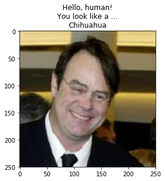

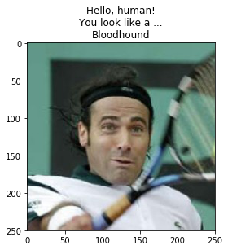

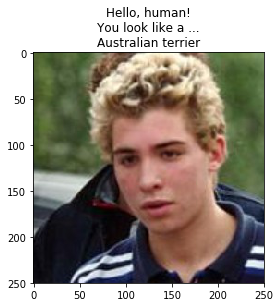

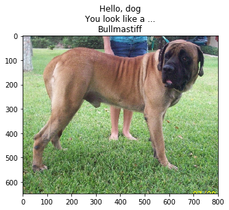

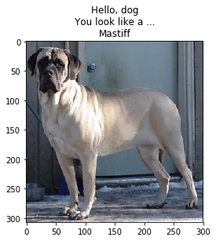

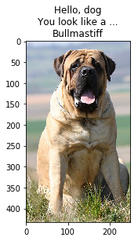

```python
## Execute your algorithm from Step 6 on
## at least 6 images on your computer.
## Feel free to use as many code cells as needed.

## suggested code, below
for file in np.hstack((human_files[:3], dog_files[:3])):
    run_app(file)
```

[figure not shown]

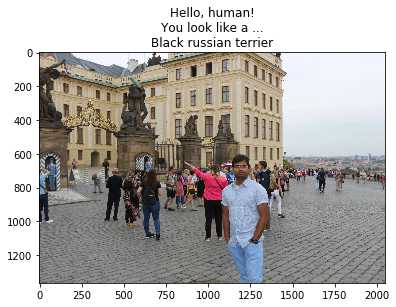

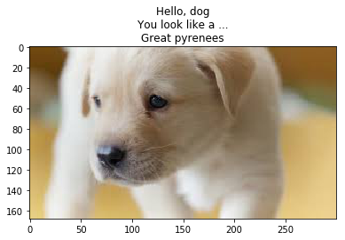

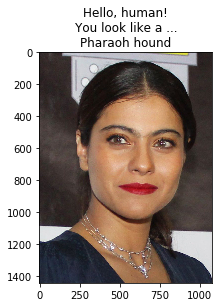

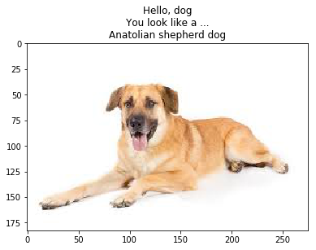

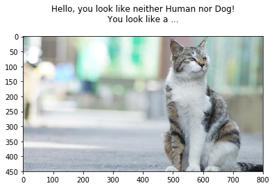

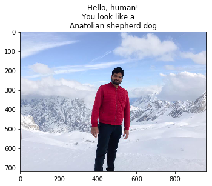

```python
## Images from my Desktop

my_sample_images = np.array(glob("/home/workspace/dog_project/my_images/*"))

## suggested code, below
for file in my_sample_images:
    run_app(file)
```